# homework4

19_jeongmin

2018년 11월 15일

### 단순선형회귀분석

- 데이터 불러오기

```r
library(readr)
salary <- read_table2("http://data.princeton.edu/wws509/datasets/salary.dat")
head(salary)
```

```
## # A tibble: 6 x 6
##   sx     rk       yr dg           yd    sl
##   <chr>  <chr> <int> <chr>     <int> <int>
## 1 male   full     25 doctorate    35 36350
## 2 male   full     13 doctorate    22 35350
## 3 male   full     10 doctorate    23 28200
## 4 female full      7 doctorate    27 26775
## 5 male   full     19 masters      30 33696
## 6 male   full     16 doctorate    21 28516
```

1. 계수 추정

```r
lm2 <- lm(sl~yd,salary)
summary(lm2)
```

```
##
## Call:
## lm(formula = sl ~ yd, data = salary)
##
## Residuals:
##     Min      1Q  Median      3Q     Max
## -9703.5 -2319.5  -437.1  2631.8 11167.3
##
## Coefficients:
##             Estimate Std. Error t value Pr(>|t|)
## (Intercept) 17502.26    1149.70  15.223  < 2e-16 ***
## yd            390.65      60.41   6.466  4.1e-08 ***
## ---
## Signif. codes:  0 '***' 0.001 '**' 0.01 '*' 0.05 '.' 0.1 ' ' 1
##
## Residual standard error: 4410 on 50 degrees of freedom
## Multiple R-squared:  0.4554, Adjusted R-squared:  0.4445
## F-statistic: 41.82 on 1 and 50 DF,  p-value: 4.102e-08
```

```r
coef(lm2)
```

```
## (Intercept)          yd
##  17502.2574    390.6451
```

회귀분석의 결과를 보면 yd의 계수는 390.6451인 것을 알 수 있다.

2. 계수의 95% 신뢰구간

```r
confint(lm2, level = 0.95)
```

```
##                  2.5 %     97.5 %
## (Intercept) 15193.0161 19811.4987
## yd            269.3063   511.9839
```

yd의 95%신뢰구간은 269.3063 ~ 511.9839이다.

3. 회귀선 시각화

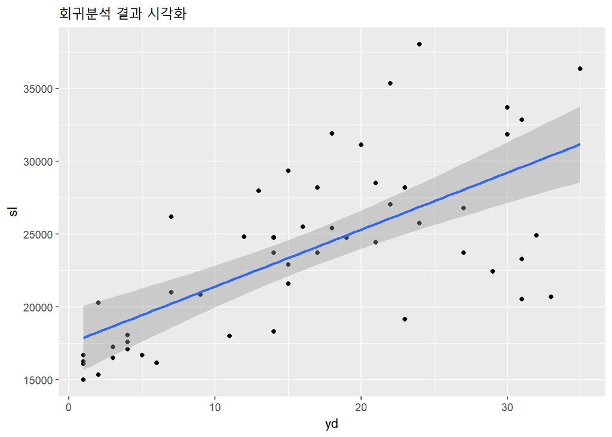

```r
library(ggplot2)
ggplot(salary, aes(x=yd, y=sl)) + geom_point() +
  geom_smooth(method="lm") + labs(title="회귀분석 결과 시각화")
```

4. 선형회귀분석 결과에 대한 진단

```r
summary(lm2)
```

```
##
## Call:
## lm(formula = sl ~ yd, data = salary)
##
## Residuals:
##     Min      1Q  Median      3Q     Max
## -9703.5 -2319.5  -437.1  2631.8 11167.3
##
## Coefficients:
##             Estimate Std. Error t value Pr(>|t|)
## (Intercept) 17502.26    1149.70  15.223  < 2e-16 ***
## yd            390.65      60.41   6.466  4.1e-08 ***
## ---
## Signif. codes:  0 '***' 0.001 '**' 0.01 '*' 0.05 '.' 0.1 ' ' 1
##
## Residual standard error: 4410 on 50 degrees of freedom
## Multiple R-squared:  0.4554, Adjusted R-squared:  0.4445
## F-statistic: 41.82 on 1 and 50 DF,  p-value: 4.102e-08
```

우선 summary 함수를 이용하여 모형의 적합도 검정 결과를 보면, y절편(Intercept)와 독립변수 yd에 대한 p-value값이 0.05보다 낮기때문에 매우 유의미하다고 볼 수 있다. 모형 전반에 대한 p-value 값도 4.102e-08로 0.05보다 낮기 때문에 통계학적으로 유의미성을 나타낸다.

R-squared 값을 보면 0.4554로 sl의 변동량의 약 46%정도를 이 모형을 통해 설명할 수 있음을 알 수 있다.

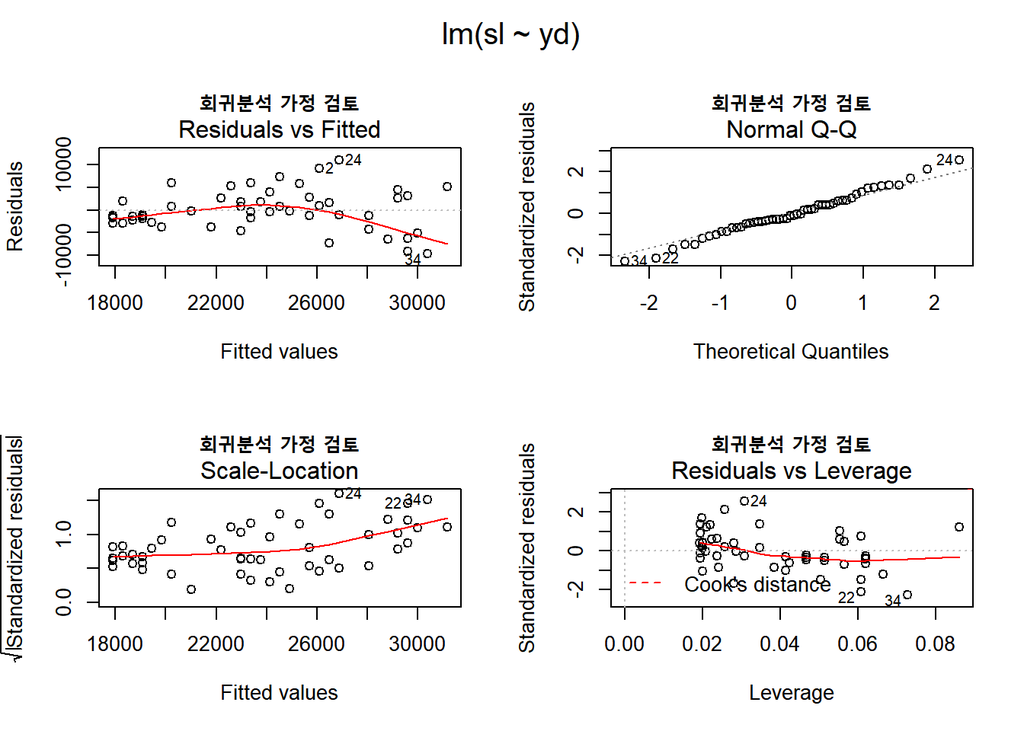

```r
par(mfrow=c(2,2),oma = c(0, 0, 2, 0))
plot(lm2, main='회귀분석 가정 검토')
```

다음으로 회귀분석 가정에 대해서 검토를 해 보았다.